NAPED · Afya São João del-Rei

Julho de 2026 · Edição 2026.2

# Semana de Desenvolvimento Docente

Uma semana dedicada à docência sustentável e ao uso da Inteligência Artificial na formação docente, reunindo a trilha de Medicina e os cursos SHE.

06 a 09 de julho de 2026 Afya São João del-Rei Relato da edição

[figure not shown]

Sobre a semana

## Formar quem forma

A Semana de Desenvolvimento Docente reuniu o corpo docente da Afya São João del-Rei em torno de uma docência mais sustentável e do uso consciente da Inteligência Artificial no ensino.

Foram quatro dias em duas trilhas paralelas — a de Medicina e a dos cursos SHE — com alinhamentos por área, oficinas práticas, uma sessão demonstrativa de IA e um encerramento que celebrou o que a equipe construiu junto.

Tema da edição

### Docência sustentável & IA

Como aliar sustentabilidade e tecnologia para transformar a experiência de ensinar e aprender na educação superior.

A semana em números

## O que a edição mobilizou

Docentes participantes

Atividades realizadas

7

Oficinas práticas

50h

Horas de formação

Participação por curso

Medicina

28

12 com ≥50% de frequência

Cursos SHE

83

67 com ≥50% de frequência

Frequência ≥ 50%

79

Presença por dia

Seg · 06/07

79

Ter · 07/07

75

Qua · 08/07

75

Programação

## Como foi cada dia

Quatro dias em duas trilhas paralelas: a de Medicina e a dos cursos SHE. Alguns momentos foram comuns a todos; outros, específicos de cada área.

Trilha Medicina Cursos SHE

1

Seg · 06/07

### Alinhamento e planejamento do semestre

A semana abriu com os professores reunidos por área para alinhar o semestre 2026/2, revisar os resultados de 2026/1 e registrar boas práticas.

Medicina

- **Alinhamento SOI**Com os especialistas de eixo · 14h · Auditório 2

Cursos SHE

- **Encontro dos coordenadores com os professores**Alinhamento do semestre, conselho de classe e formulário de boas práticas — simultaneamente nos 9 cursos: Administração, Biomedicina, Direito, Enfermagem, Fisioterapia, Nutrição, Odontologia, Psicologia e Veterinária.

Registros do dia

[figure not shown]

[figure not shown]

[figure not shown]

[figure not shown]

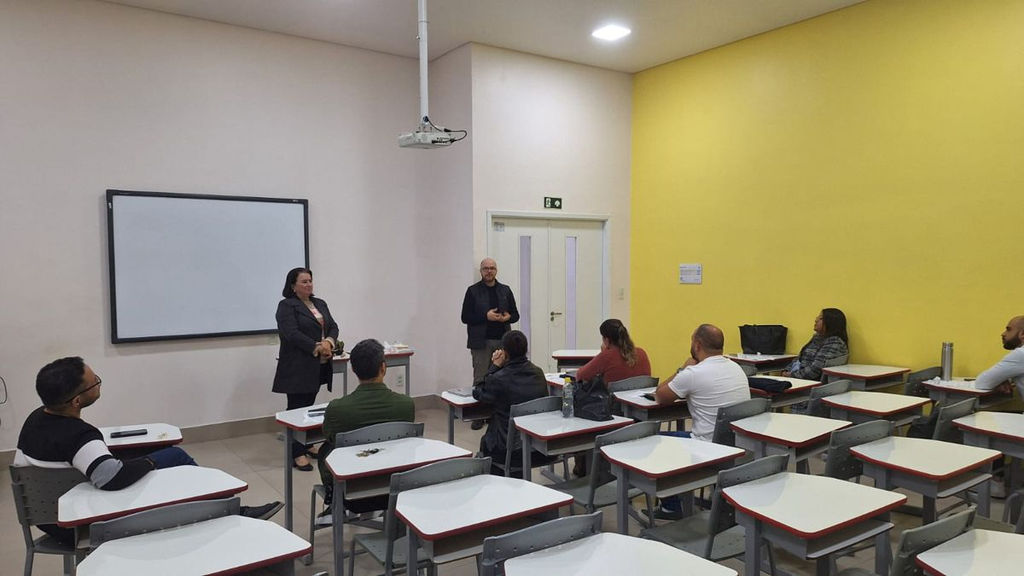

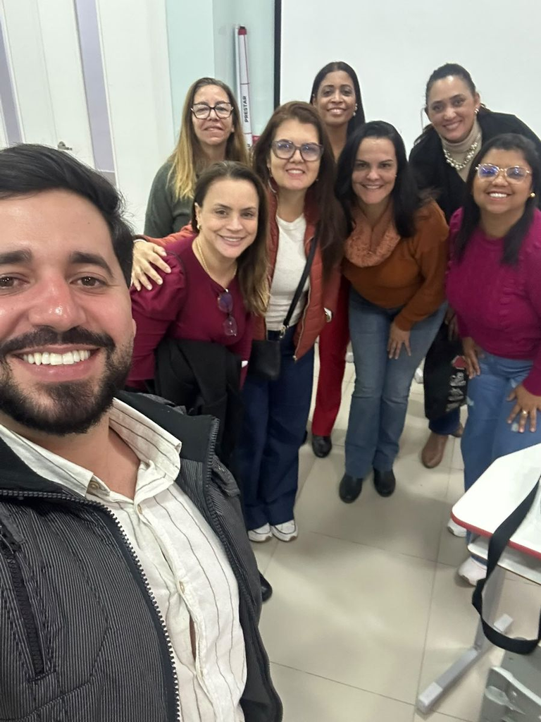

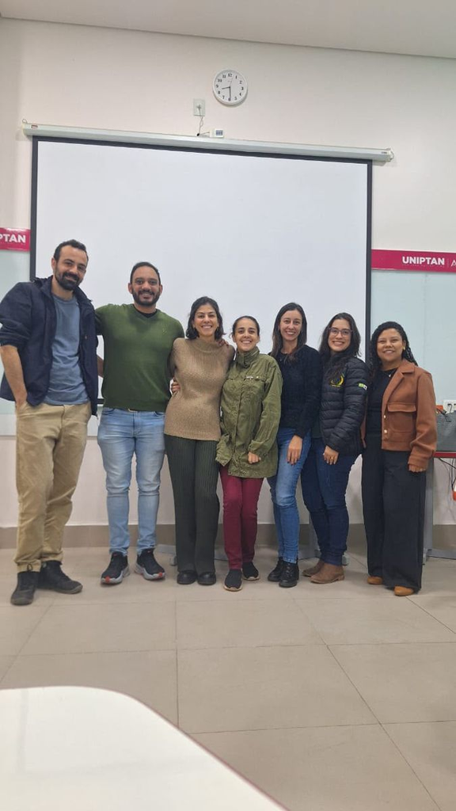

[figure not shown]

[figure not shown]

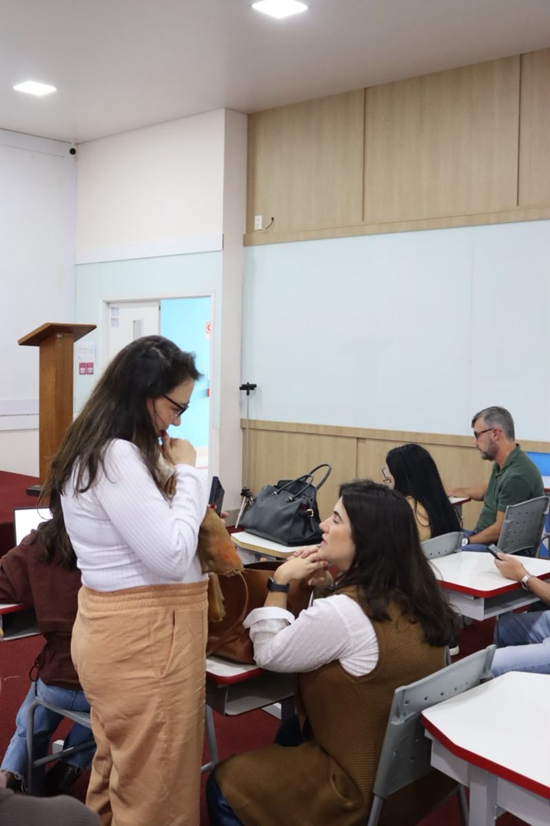

[video not shown]

Vídeo · Alinhamento SOI

2

Ter · 07/07

### IA na docência e planos de ensino

Ponto alto da semana: a sessão demonstrativa **"Agentes de IA na docência"**, com o Prof. Dr. Henrique Alvarenga, no Auditório — aberta a todos os professores.

Medicina

- **Oficina de feedback (SOI)**Com Elihege · 8h
- **Elaboração de itens / Questione (HAM e SOI)**Com Cássia e Alessandra · 21h · Lab. de Informática

Cursos SHE

- **Preenchimento dos planos de ensino**Com o NAPED e os coordenadores de curso · 21h
- **Treinamento em simulação realística**Fisioterapia, com Gustavo Del Vecchia · 21h

Registros do dia

[figure not shown]

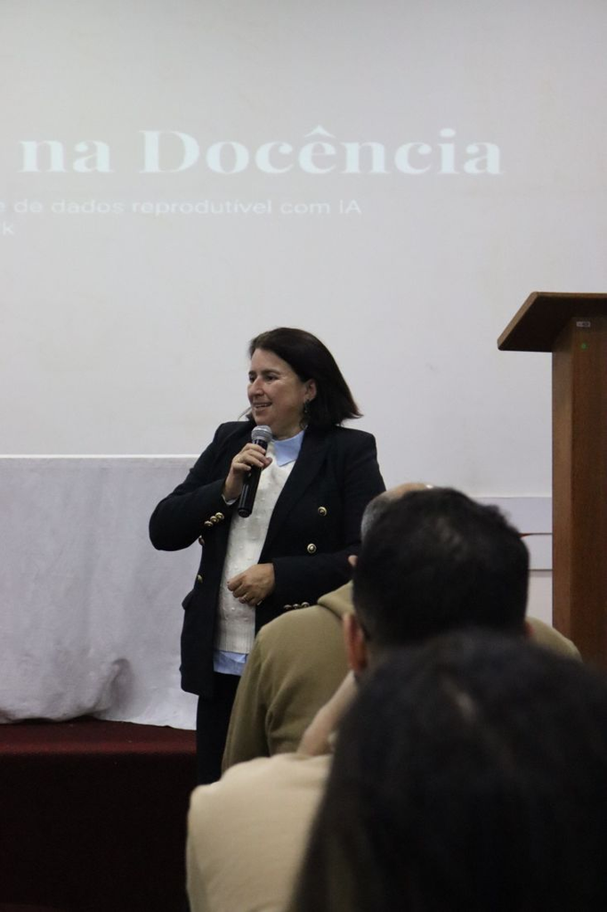

[figure not shown]

[figure not shown]

[figure not shown]

[figure not shown]

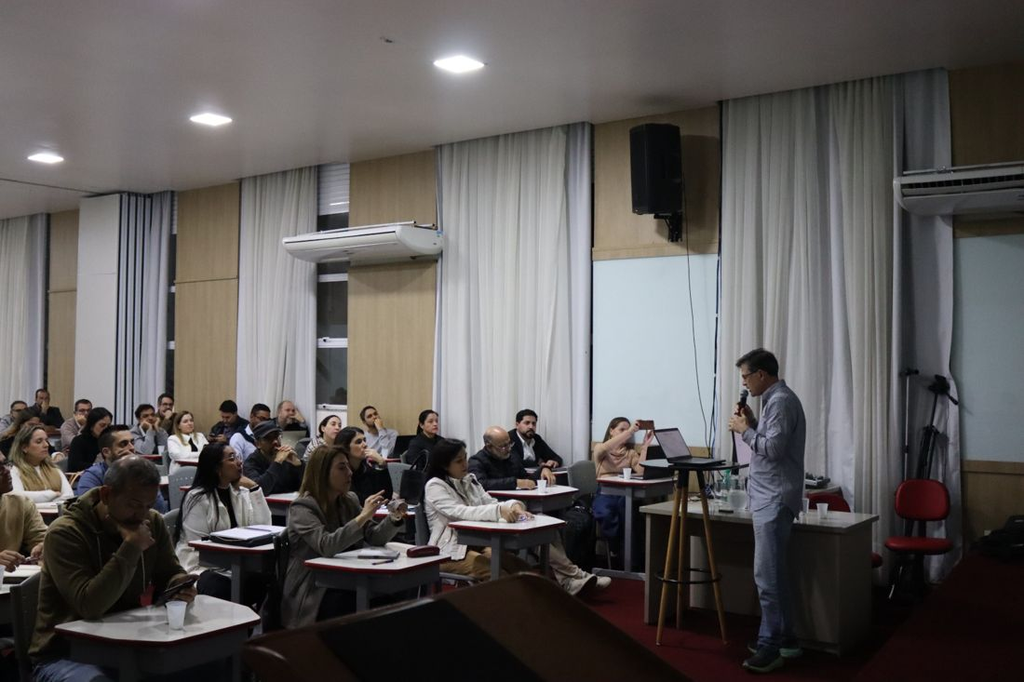

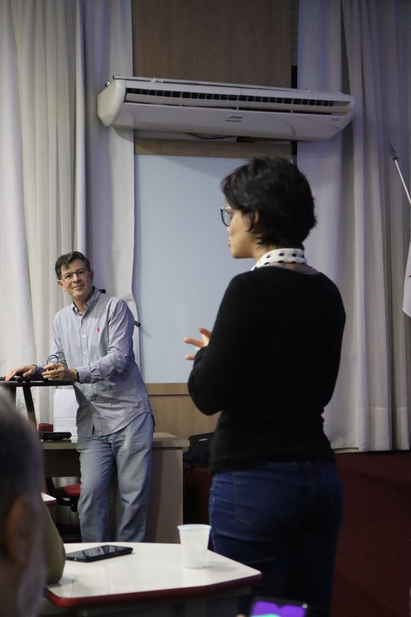

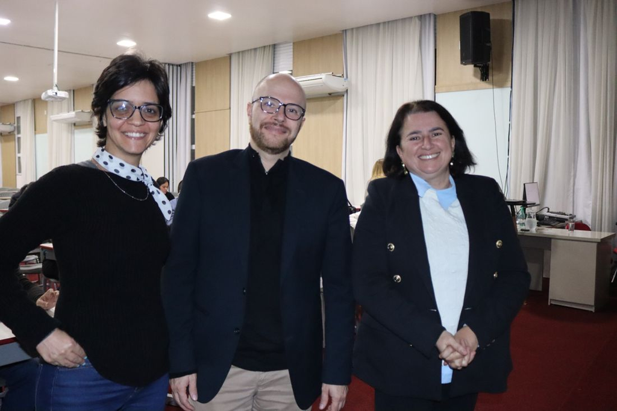

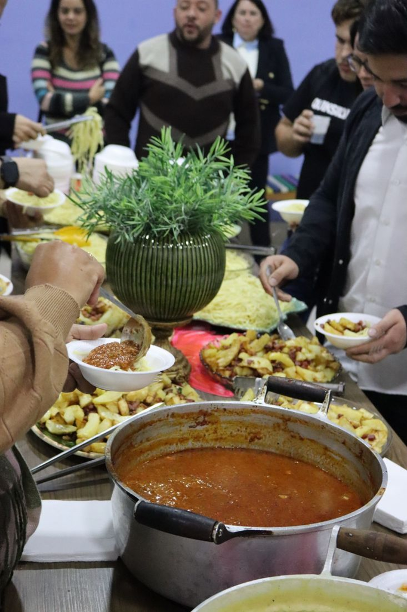

3

Qua · 08/07

### Oficinas por eixo e por curso

Dia dedicado às oficinas práticas, cada área aprofundando os temas mais relevantes para o seu contexto.

Medicina

- **PIEPE — Enamed no PIEPE**Com Alessandra · 10h
- **HAM**Apresentação do eixo, avaliação diária e OSCE
- **C.I.**Apresentação do novo sistema de avaliação
- **Construindo o IESC que queremos**Eixo IESC

Cursos SHE

- **ENADE**Com Alessandra
- **Elaboração de Itens**Com Daniel Riani
- **NotebookLM**Com Simone
- **Oficina de Feedback e Alunos PEI**Com Elihege — entre outras oficinas específicas de cada curso

Registros do dia Oficina — Como oferecer feedback

[figure not shown]

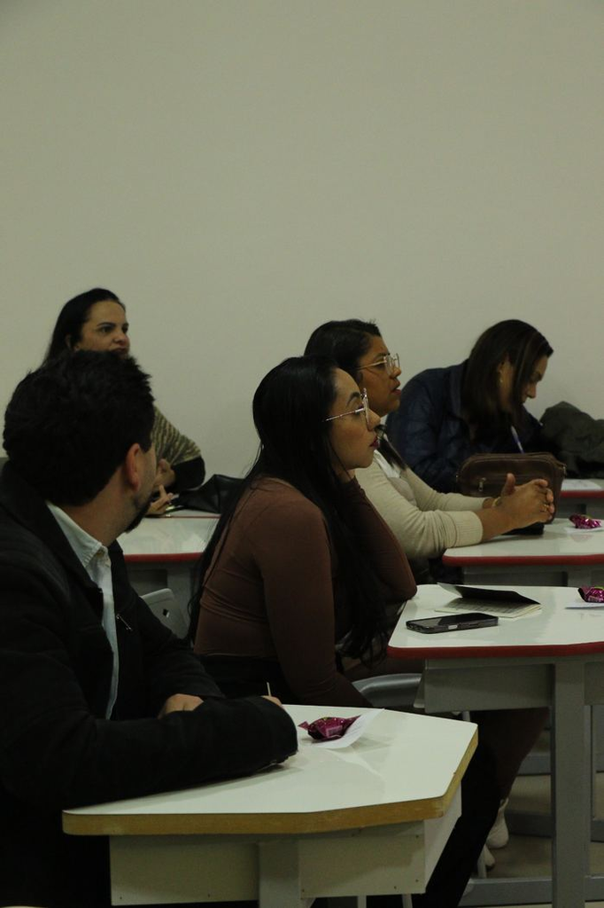

Oficina — Prompt reverso (Direito)

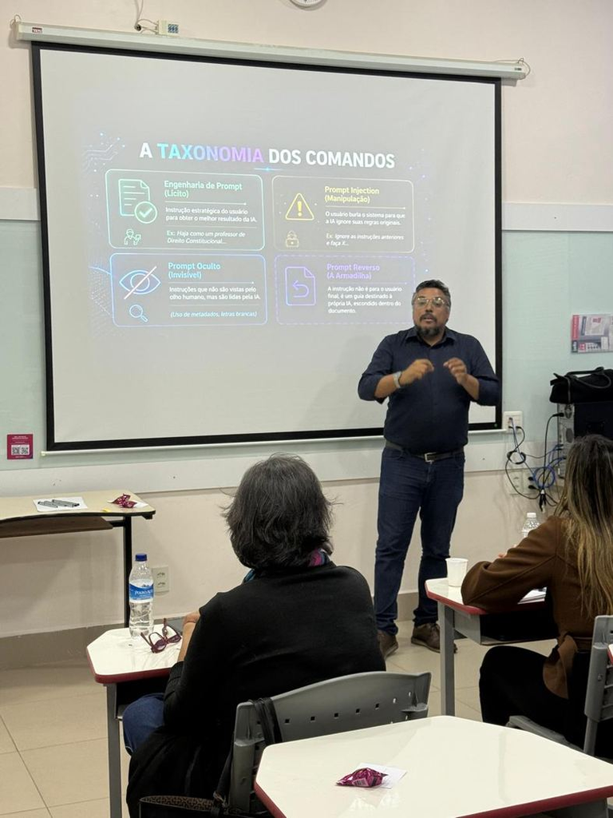

[figure not shown]

Alinhamento do eixo HAM (Medicina)

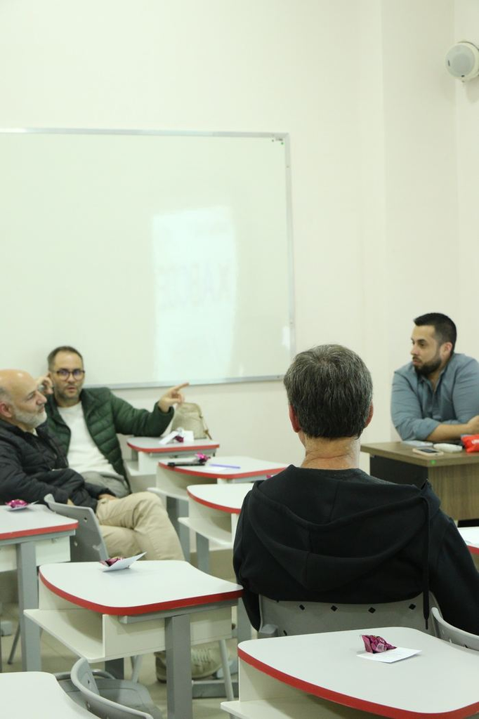

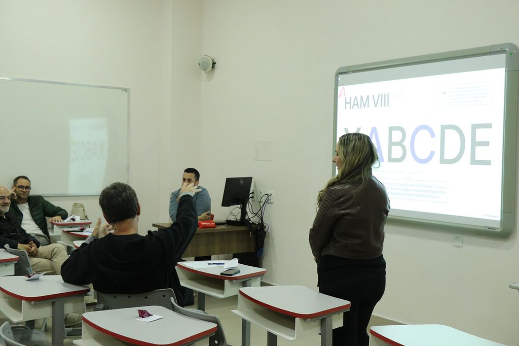

Oficina — NotebookLM

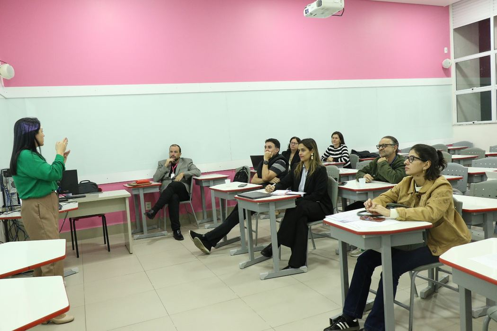

[figure not shown]